# Data Mining & Machine Learning: Final Project

## Best Subset Selection Method for Regression

```r
library(MASS) # MASS package must be installed
library(leaps) # leaps package must be installed
attach(Boston) # attaching Boston data to R’s search path
str(Boston) # displays structure of data.
```

```
## 'data.frame':    506 obs. of  14 variables:
##  $ crim   : num  0.00632 0.02731 0.02729 0.03237 0.06905 ...
##  $ zn     : num  18 0 0 0 0 0 12.5 12.5 12.5 12.5 ...
##  $ indus  : num  2.31 7.07 7.07 2.18 2.18 2.18 7.87 7.87 7.87 7.87 ...
##  $ chas   : int  0 0 0 0 0 0 0 0 0 0 ...
##  $ nox    : num  0.538 0.469 0.469 0.458 0.458 0.458 0.524 0.524 0.524 0.524 ...
##  $ rm     : num  6.58 6.42 7.18 7 7.15 ...
##  $ age    : num  65.2 78.9 61.1 45.8 54.2 58.7 66.6 96.1 100 85.9 ...
##  $ dis    : num  4.09 4.97 4.97 6.06 6.06 ...
##  $ rad    : int  1 2 2 3 3 3 5 5 5 5 ...
##  $ tax    : num  296 242 242 222 222 222 311 311 311 311 ...
##  $ ptratio: num  15.3 17.8 17.8 18.7 18.7 18.7 15.2 15.2 15.2 15.2 ...
##  $ black  : num  397 397 393 395 397 ...
##  $ lstat  : num  4.98 9.14 4.03 2.94 5.33 ...
##  $ medv   : num  24 21.6 34.7 33.4 36.2 28.7 22.9 27.1 16.5 18.9 ...
```

```r
names(Boston) # shows names of columns (variables) of Boston data set. To know more about this data set, you may type ?Boston in the R Console window.
```

```
##  [1] "crim"    "zn"      "indus"   "chas"    "nox"     "rm"      "age"
##  [8] "dis"     "rad"     "tax"     "ptratio" "black"   "lstat"   "medv"
```

```r
regfit.full = regsubsets(medv~., data = Boston, nvmax = 13) # Question 4.1: What does this line of code do? Why do we use nvmax = 13 in this code?
summary(regfit.full) # Question 4.2: What does this line of code print? Which variables are included in the best eight-variable model?
```

```
## Subset selection object
## Call: regsubsets.formula(medv ~ ., data = Boston, nvmax = 13)
## 13 Variables  (and intercept)
##         Forced in Forced out
## crim        FALSE      FALSE
## zn          FALSE      FALSE
## indus       FALSE      FALSE
## chas        FALSE      FALSE
## nox         FALSE      FALSE
## rm          FALSE      FALSE
## age         FALSE      FALSE
## dis         FALSE      FALSE
## rad         FALSE      FALSE
## tax         FALSE      FALSE
## ptratio     FALSE      FALSE
## black       FALSE      FALSE
## lstat       FALSE      FALSE
## 1 subsets of each size up to 13
## Selection Algorithm: exhaustive
##           crim zn  indus chas nox rm  age dis rad tax ptratio black lstat
## 1  ( 1 )  " "  " " " "   " "  " " " " " " " " " " " " " "     " "   "*"
## 2  ( 1 )  " "  " " " "   " "  " " "*" " " " " " " " " " "     " "   "*"
## 3  ( 1 )  " "  " " " "   " "  " " "*" " " " " " " " " "*"     " "   "*"
## 4  ( 1 )  " "  " " " "   " "  " " "*" " " "*" " " " " "*"     " "   "*"
## 5  ( 1 )  " "  " " " "   " "  "*" "*" " " "*" " " " " "*"     " "   "*"
## 6  ( 1 )  " "  " " " "   "*"  "*" "*" " " "*" " " " " "*"     " "   "*"
## 7  ( 1 )  " "  " " " "   "*"  "*" "*" " " "*" " " " " "*"     "*"   "*"
## 8  ( 1 )  " "  "*" " "   "*"  "*" "*" " " "*" " " " " "*"     "*"   "*"
## 9  ( 1 )  "*"  " " " "   "*"  "*" "*" " " "*" "*" " " "*"     "*"   "*"
## 10  ( 1 ) "*"  "*" " "   " "  "*" "*" " " "*" "*" "*" "*"     "*"   "*"
## 11  ( 1 ) "*"  "*" " "   "*"  "*" "*" " " "*" "*" "*" "*"     "*"   "*"
## 12  ( 1 ) "*"  "*" "*"   "*"  "*" "*" " " "*" "*" "*" "*"     "*"   "*"
## 13  ( 1 ) "*"  "*" "*"   "*"  "*" "*" "*" "*" "*" "*" "*"     "*"   "*"
```

```r
reg.summary = summary(regfit.full)
names(reg.summary) # Question 4.3: What does this line of code print?
```

```
## [1] "which"  "rsq"    "rss"    "adjr2"  "cp"     "bic"    "outmat" "obj"
```

```r
reg.summary$rsq
```

```
##  [1] 0.5441463 0.6385616 0.6786242 0.6903077 0.7080893 0.7157742 0.7221614
##  [8] 0.7266079 0.7301704 0.7352631 0.7405823 0.7406412 0.7406427
```

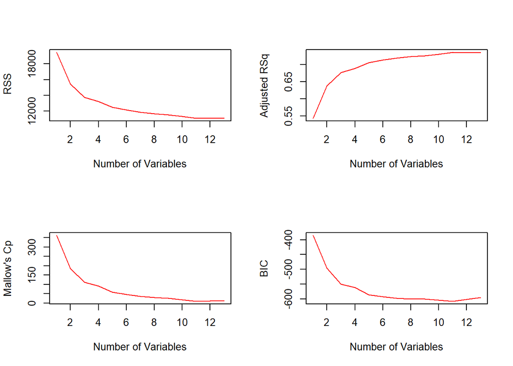

```r
par(mfrow = c(2,2)) # Question 4.4: What does this line of code do?
plot(reg.summary$rss, xlab = "Number of Variables", ylab = " RSS", type = "l", col="red")
plot(reg.summary$adjr2, xlab = "Number of Variables", ylab= "Adjusted RSq", type = "l", col="red")
plot(reg.summary$cp, xlab = "Number of Variables", ylab = "Mallow's Cp", type = "l", col="red")
plot(reg.summary$bic, xlab = "Number of Variables", ylab= "BIC", type = "l", col="red")
```

```r
# Question 4.5: What is the result of running the four plots?
which.max(reg.summary$adjr2) # Question 4.6: What does this line of code print? What does it denote?
```

```
## [1] 11
```

```r
which.min(reg.summary$cp) # Question 4.7: What does this line of code print? What does it denote?
```

```
## [1] 11
```

```r
which.min(reg.summary$bic) # Question 4.8: What does this line of code print? What does it denote?
```

```
## [1] 11
```

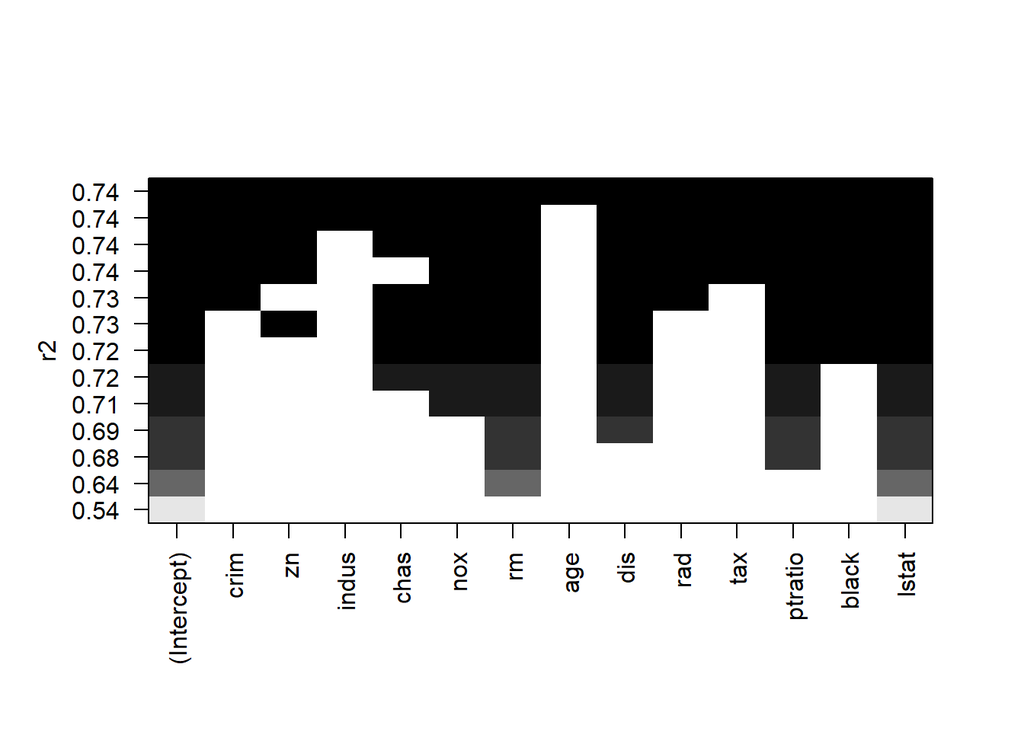

```r
par(mfrow = c(1,1))
plot(regfit.full, scale = "r2")
```

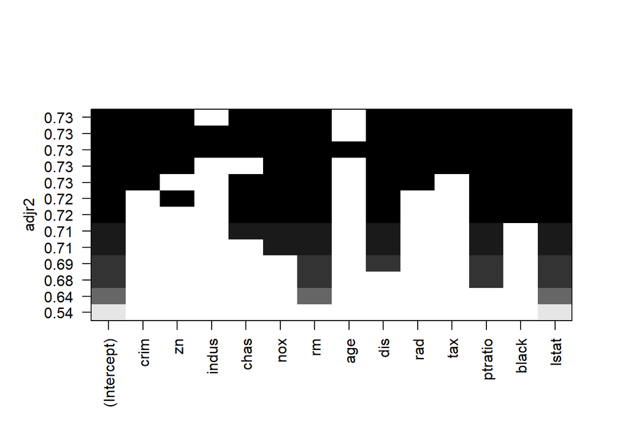

```r
plot(regfit.full, scale = "adjr2")
```

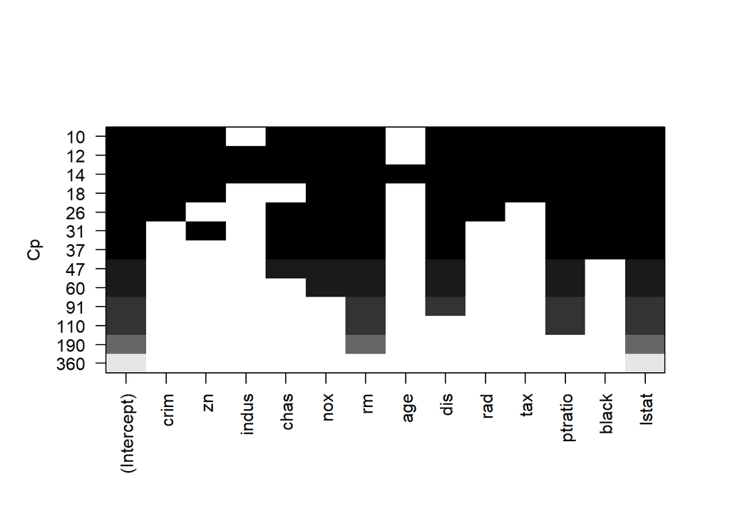

```r
plot(regfit.full, scale = "Cp")
```

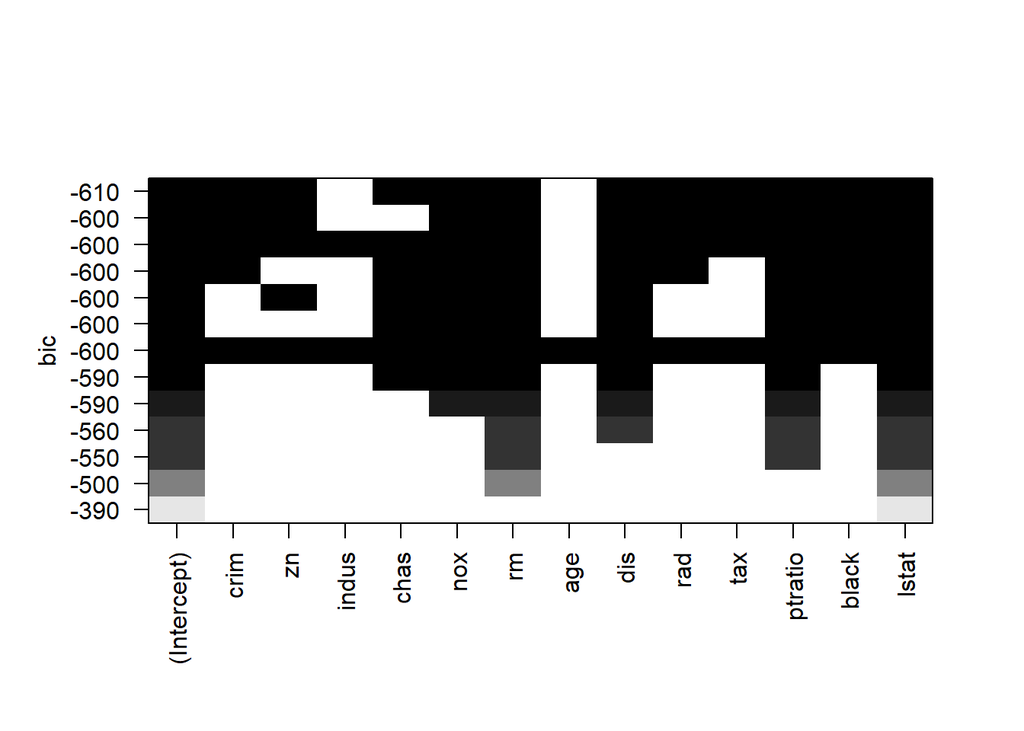

```r
plot(regfit.full, scale = "bic")
```

```r
# Question 4.9: What is the result of running the four plots? Explain what these plots denote.
# Question 4.10: Using answers to Questions 4.6 through 4.8, which model is considered the best model?

regfit.fwd <- regsubsets (medv ~ ., data = Boston, nvmax = 13, method = "forward")
summary (regfit.fwd)
```

```
## Subset selection object
## Call: regsubsets.formula(medv ~ ., data = Boston, nvmax = 13, method = "forward")
## 13 Variables  (and intercept)
##         Forced in Forced out
## crim        FALSE      FALSE
## zn          FALSE      FALSE
## indus       FALSE      FALSE
## chas        FALSE      FALSE
## nox         FALSE      FALSE
## rm          FALSE      FALSE
## age         FALSE      FALSE
## dis         FALSE      FALSE
## rad         FALSE      FALSE
## tax         FALSE      FALSE
## ptratio     FALSE      FALSE
## black       FALSE      FALSE
## lstat       FALSE      FALSE
## 1 subsets of each size up to 13
## Selection Algorithm: forward
##           crim zn  indus chas nox rm  age dis rad tax ptratio black lstat
## 1  ( 1 )  " "  " " " "   " "  " " " " " " " " " " " " " "     " "   "*"
## 2  ( 1 )  " "  " " " "   " "  " " "*" " " " " " " " " " "     " "   "*"
## 3  ( 1 )  " "  " " " "   " "  " " "*" " " " " " " " " "*"     " "   "*"
## 4  ( 1 )  " "  " " " "   " "  " " "*" " " "*" " " " " "*"     " "   "*"
## 5  ( 1 )  " "  " " " "   " "  "*" "*" " " "*" " " " " "*"     " "   "*"
## 6  ( 1 )  " "  " " " "   "*"  "*" "*" " " "*" " " " " "*"     " "   "*"
## 7  ( 1 )  " "  " " " "   "*"  "*" "*" " " "*" " " " " "*"     "*"   "*"
## 8  ( 1 )  " "  "*" " "   "*"  "*" "*" " " "*" " " " " "*"     "*"   "*"
## 9  ( 1 )  "*"  "*" " "   "*"  "*" "*" " " "*" " " " " "*"     "*"   "*"
## 10  ( 1 ) "*"  "*" " "   "*"  "*" "*" " " "*" "*" " " "*"     "*"   "*"
## 11  ( 1 ) "*"  "*" " "   "*"  "*" "*" " " "*" "*" "*" "*"     "*"   "*"
## 12  ( 1 ) "*"  "*" "*"   "*"  "*" "*" " " "*" "*" "*" "*"     "*"   "*"
## 13  ( 1 ) "*"  "*" "*"   "*"  "*" "*" "*" "*" "*" "*" "*"     "*"   "*"
```

```r
regfit.bwd <- regsubsets (medv ~ ., data = Boston, nvmax = 13, method = "backward")
summary (regfit.bwd)
```

```
## Subset selection object
## Call: regsubsets.formula(medv ~ ., data = Boston, nvmax = 13, method = "backward")
## 13 Variables  (and intercept)
##         Forced in Forced out
## crim        FALSE      FALSE
## zn          FALSE      FALSE
## indus       FALSE      FALSE
## chas        FALSE      FALSE
## nox         FALSE      FALSE
## rm          FALSE      FALSE
## age         FALSE      FALSE
## dis         FALSE      FALSE
## rad         FALSE      FALSE
## tax         FALSE      FALSE
## ptratio     FALSE      FALSE
## black       FALSE      FALSE
## lstat       FALSE      FALSE
## 1 subsets of each size up to 13
## Selection Algorithm: backward
##           crim zn  indus chas nox rm  age dis rad tax ptratio black lstat
## 1  ( 1 )  " "  " " " "   " "  " " " " " " " " " " " " " "     " "   "*"
## 2  ( 1 )  " "  " " " "   " "  " " "*" " " " " " " " " " "     " "   "*"
## 3  ( 1 )  " "  " " " "   " "  " " "*" " " " " " " " " "*"     " "   "*"
## 4  ( 1 )  " "  " " " "   " "  " " "*" " " "*" " " " " "*"     " "   "*"
## 5  ( 1 )  " "  " " " "   " "  "*" "*" " " "*" " " " " "*"     " "   "*"
## 6  ( 1 )  " "  " " " "   " "  "*" "*" " " "*" " " " " "*"     "*"   "*"
## 7  ( 1 )  " "  " " " "   " "  "*" "*" " " "*" "*" " " "*"     "*"   "*"
## 8  ( 1 )  "*"  " " " "   " "  "*" "*" " " "*" "*" " " "*"     "*"   "*"
## 9  ( 1 )  "*"  " " " "   " "  "*" "*" " " "*" "*" "*" "*"     "*"   "*"
## 10  ( 1 ) "*"  "*" " "   " "  "*" "*" " " "*" "*" "*" "*"     "*"   "*"
## 11  ( 1 ) "*"  "*" " "   "*"  "*" "*" " " "*" "*" "*" "*"     "*"   "*"
## 12  ( 1 ) "*"  "*" "*"   "*"  "*" "*" " " "*" "*" "*" "*"     "*"   "*"
## 13  ( 1 ) "*"  "*" "*"   "*"  "*" "*" "*" "*" "*" "*" "*"     "*"   "*"
```

```r
coef(regfit.fwd, 11)
```

```
##   (Intercept)          crim            zn          chas           nox
##  36.341145004  -0.108413345   0.045844929   2.718716303 -17.376023429
##            rm           dis           rad           tax       ptratio
##   3.801578840  -1.492711460   0.299608454  -0.011777973  -0.946524570
##         black         lstat
##   0.009290845  -0.522553457
```

```r
coef(regfit.bwd, 11)
```

```
##   (Intercept)          crim            zn          chas           nox
##  36.341145004  -0.108413345   0.045844929   2.718716303 -17.376023429
##            rm           dis           rad           tax       ptratio
##   3.801578840  -1.492711460   0.299608454  -0.011777973  -0.946524570
##         black         lstat
##   0.009290845  -0.522553457
```

## Best Subset Selection Summary of Output

### Question 4.2

This line of code prints the best variable selection for each model size. For an 8 variable model, the best variables are zn, chas, nox, rm, dis, ptratio, black, and lstat.

### Question 4.3

This line of code produces the column names for the regfit.full model.

### Question 4.4

This line of code specifies the plot matrix parameters for the plot matrix to be generated in the proceeding lines of code. In this case, a 2x2 plot matrix is called for.

### Question 4.5

These lines of codes produce four different plots. The plots indicate the best number of variables to select for the model based on values for RSS, adjusted r2, Mallow’s Cp, and BIC, respectively. According to the plots produced, the best number of variables to include is 11.

### Question 4.6

This line of code denotes that the value for adjusted r2 occurs with an 11 variable model.

### Question 4.7

This line of code denotes that the value for Mallow’s Cp occurs with an 11 variable model.

### Question 4.8

This line of code denotes that the value for BIC occurs with an 11 variable model.

### Question 4.9

These plots visually plot variable significance based on their respective RSS, adjusted r2, Mallow’s Cp, and BIC values. According to these plots, the most significant variables are rm and lstat.

### Question 4.10

By running the lines of code for questions 4.6 through 4.8, an 11 variable model is determined to be the best model.

### Question 6

The best variable for a 13 variable model determined using forward selection include: crim, zn, indus, chas, nox, rm, age, dis, rad, tax, ptratio, black, and lstat. For an 11 variable model, which was determined to be the best model in Question 4.10, forward selection determined crim, zn, chas, nox, rm, dis, rad, tax, ptratio, black, and lstat to be the best variables to include in the model.

The best variable for a 13 variable model determined using backward selection include all of the variables selected for the best 13 variable model using forward selection. Backward selection also determined crim, zn, chas, nox, rm, dis, rad, tax, ptratio, black, and lstat to be the best variables to include in the model.

# Section 2: Unsupervised Learning

## Principal Components Analysis

```r
states <- row.names (USArrests)
states
```

```
##  [1] "Alabama"        "Alaska"         "Arizona"        "Arkansas"
##  [5] "California"     "Colorado"       "Connecticut"    "Delaware"
##  [9] "Florida"        "Georgia"        "Hawaii"         "Idaho"
## [13] "Illinois"       "Indiana"        "Iowa"           "Kansas"
## [17] "Kentucky"       "Louisiana"      "Maine"          "Maryland"
## [21] "Massachusetts"  "Michigan"       "Minnesota"      "Mississippi"
## [25] "Missouri"       "Montana"        "Nebraska"       "Nevada"
## [29] "New Hampshire"  "New Jersey"     "New Mexico"     "New York"
## [33] "North Carolina" "North Dakota"   "Ohio"           "Oklahoma"
## [37] "Oregon"         "Pennsylvania"   "Rhode Island"   "South Carolina"
## [41] "South Dakota"   "Tennessee"      "Texas"          "Utah"
## [45] "Vermont"        "Virginia"       "Washington"     "West Virginia"
## [49] "Wisconsin"      "Wyoming"
```

```r
names(USArrests)
```

```
## [1] "Murder"   "Assault"  "UrbanPop" "Rape"
```

```r
apply(USArrests, 2, mean)
```

```
##   Murder  Assault UrbanPop     Rape
##    7.788  170.760   65.540   21.232
```

```r
apply(USArrests , 2, var)
```

```
##     Murder    Assault   UrbanPop       Rape
##   18.97047 6945.16571  209.51878   87.72916
```

```r
pr.out <- prcomp (USArrests, scale = TRUE)
names(pr.out)
```

```
## [1] "sdev"     "rotation" "center"   "scale"    "x"
```

```r
pr.out$center
```

```
##   Murder  Assault UrbanPop     Rape
##    7.788  170.760   65.540   21.232
```

```r
pr.out$rotation
```

```
##                 PC1        PC2        PC3         PC4
## Murder   -0.5358995 -0.4181809  0.3412327  0.64922780
## Assault  -0.5831836 -0.1879856  0.2681484 -0.74340748
## UrbanPop -0.2781909  0.8728062  0.3780158  0.13387773
## Rape     -0.5434321  0.1673186 -0.8177779  0.08902432
```

```r
dim(pr.out$x)
```

```
## [1] 50  4
```

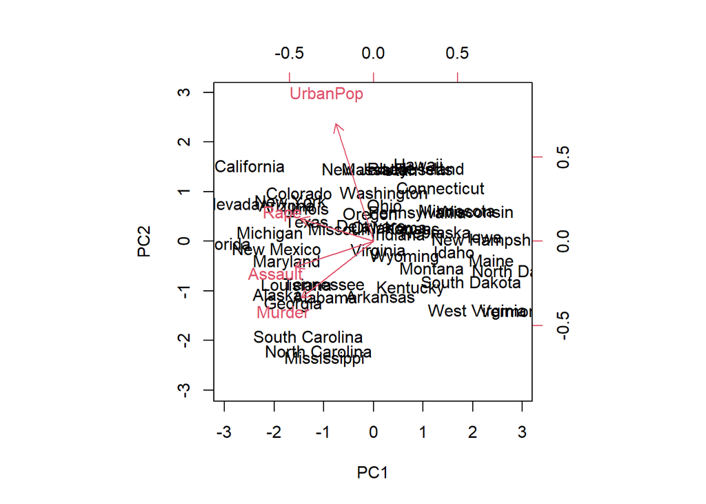

```r
biplot(pr.out, scale = 0)
```

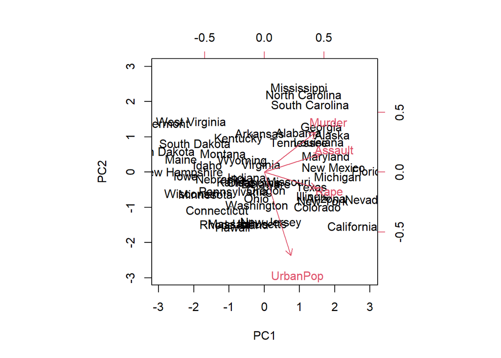

```r
pr.out$rotation = -pr.out$rotation
pr.out$x = -pr.out$x
biplot(pr.out, scale = 0)
```

```r
pr.out$sdev
```

```
## [1] 1.5748783 0.9948694 0.5971291 0.4164494
```

```r
pr.var <- pr.out$sdev^2
pr.var
```

```
## [1] 2.4802416 0.9897652 0.3565632 0.1734301
```

```r
pve <- pr.var / sum (pr.var)
pve
```

```
## [1] 0.62006039 0.24744129 0.08914080 0.04335752
```

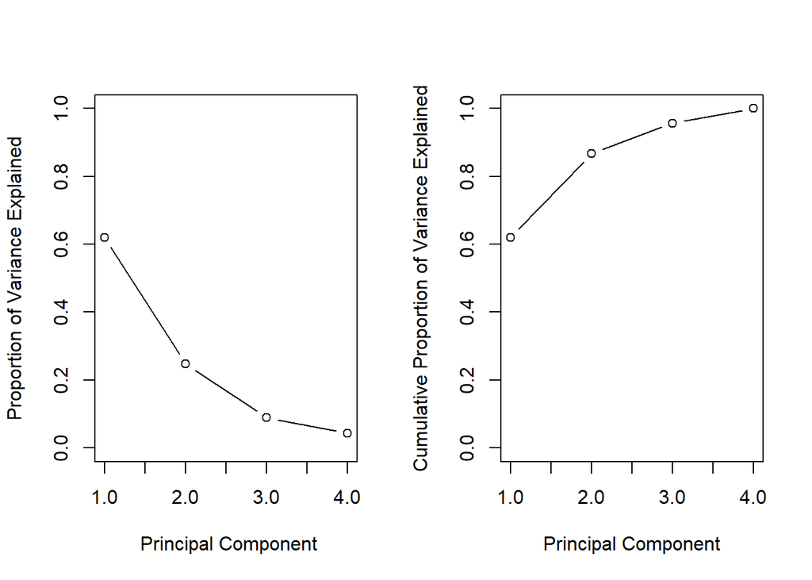

```r
par(mfrow = c(1, 2))
plot(pve, xlab = " Principal Component", ylab = " Proportion of Variance Explained ", ylim = c(0, 1), type = "b")
plot(cumsum (pve), xlab = " Principal Component ", ylab = " Cumulative Proportion of Variance Explained ", ylim = c(0, 1), type = "b")
```

## Principal Component Analysis Summary of Output

### Question 7

This R code chunk determines principal components using the prcomp() function. In this case, the principal components are determined for USArrests dataset using a four dimensional model that includes the variables Murder, Assault, UrbanPop, and Rape.

Using the apply() function, the mean and variance for each of the variables was determined to be as follows: Murder (mean = 7..79, var = 18.97), Assault (mean = 170.76, var = 6945.17), UrbanPop (mean = 65.54, var = 209.52), and Rape (mean = 21.23, var = 87.73). Each variable was scaled by setting scale = TRUE in the model since the values for the variables are in different units. Scaling the variables sets mean = 0 and var = 1 for each of the variables through standardization of the variable values.

The column names for the pr.out model are sdev, rotation, center, scale, and x. The column of interest in determining the principal components for the model is the rotation column. According to the calculated values for rotation, the principal components are as follows: 1st principal component (PC1) = Murder, Assault, and Rape; 2nd principal component (PC2) = UrbanPop.

The R code chunk also calculates the variance for each principal component, and then calculates the porpotion of variance explained by each component. The PVE value for PC1 is 0.62 and is 0.25 for PC2, meaning that the variance for the variables Murder, Rape, Assault, and UrbanPop explain 87% of the variance in the model. The plot matrix produced by the subsequent lines of code reflect the PVE and cumulative PVE by each principal component. The function cumsum() then computes the cumulative sum of the elements of vector, a.

## K-Means Clustering

```r
set.seed (2)
x <- matrix ( rnorm (50 * 2), ncol = 2)
x[1:25, 1] <- x[1:25, 1] + 3
x[1:25, 2] <- x[1:25, 2] - 4

km.out <- kmeans (x, 2, nstart = 20)

km.out$cluster
```

```
##  [1] 1 1 1 1 1 1 1 1 1 1 1 1 1 1 1 1 1 1 1 1 1 1 1 1 1 2 2 2 2 2 2 2 2 2 2 2 2 2
## [39] 2 2 2 2 2 2 2 2 2 2 2 2
```

```r
par (mfrow = c(1, 2))
plot (x, col = (km.out$cluster + 1),
main = "K- Means Clustering Results with K = 2",
xlab = "", ylab = "", pch = 20, cex = 2)

set.seed (4)
km.out <- kmeans (x, 3, nstart = 20)
km.out
```

```
## K-means clustering with 3 clusters of sizes 17, 23, 10
##
## Cluster means:
##         [,1]        [,2]
## 1  3.7789567 -4.56200798
## 2 -0.3820397 -0.08740753
## 3  2.3001545 -2.69622023
##
## Clustering vector:
##  [1] 1 3 1 3 1 1 1 3 1 3 1 3 1 3 1 3 1 1 1 1 1 3 1 1 1 2 2 2 2 2 2 2 2 2 2 2 2 2
## [39] 2 2 2 2 2 3 2 3 2 2 2 2
##
## Within cluster sum of squares by cluster:
## [1] 25.74089 52.67700 19.56137
##  (between_SS / total_SS =  79.3 %)
##
## Available components:
##
## [1] "cluster"      "centers"      "totss"        "withinss"     "tot.withinss"
## [6] "betweenss"    "size"         "iter"         "ifault"
```

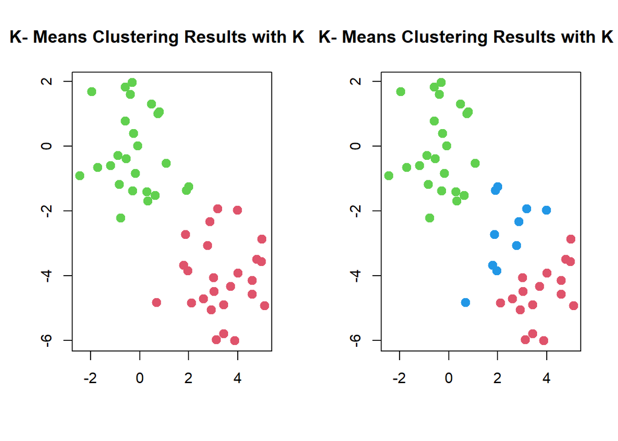

```r
plot (x, col = (km.out$cluster + 1),
main = "K- Means Clustering Results with K = 3",
xlab = "", ylab = "", pch = 20, cex = 2)
```

```r
set.seed (4)
km.out <- kmeans (x, 3, nstart = 1)
km.out$tot.withinss
```

```
## [1] 104.3319
```

```r
km.out <- kmeans (x, 3, nstart = 20)
km.out$tot.withinss
```

```
## [1] 97.97927
```

## Hierarchical Clustering

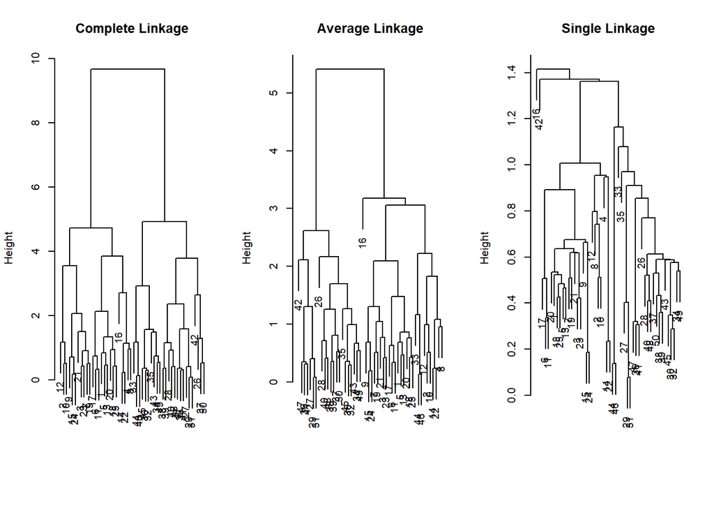

```r
hc.complete <- hclust ( dist (x), method = "complete")
hc.average <- hclust ( dist (x), method = "average")
 hc.single <- hclust ( dist (x), method = "single")

par (mfrow = c(1, 3))
plot (hc.complete, main = " Complete Linkage ", xlab = "", sub = "", cex = .9)
plot (hc.average , main = " Average Linkage ", xlab = "", sub = "", cex = .9)
plot (hc.single, main = " Single Linkage ", xlab = "", sub = "", cex = .9)
```

```r
cutree (hc.complete, 2)
```

```
##  [1] 1 1 1 1 1 1 1 1 1 1 1 1 1 1 1 1 1 1 1 1 1 1 1 1 1 2 2 2 2 2 2 2 2 2 2 2 2 2
## [39] 2 2 2 2 2 2 2 2 2 2 2 2
```

```r
cutree (hc.average, 2)
```

```
##  [1] 1 1 1 1 1 1 1 1 1 1 1 1 1 1 1 1 1 1 1 1 1 1 1 1 1 2 2 2 2 2 2 2 1 2 2 2 2 2
## [39] 2 2 2 2 2 1 2 1 2 2 2 2
```

```r
cutree (hc.single, 2)
```

```
##  [1] 1 1 1 1 1 1 1 1 1 1 1 1 1 1 1 2 1 1 1 1 1 1 1 1 1 1 1 1 1 1 1 1 1 1 1 1 1 1
## [39] 1 1 1 1 1 1 1 1 1 1 1 1
```

```r
cutree (hc.single, 4)
```

```
##  [1] 1 1 1 1 1 1 1 1 1 1 1 1 1 1 1 2 1 1 1 1 1 1 1 1 1 3 3 3 3 3 3 3 3 3 3 3 3 3
## [39] 3 3 3 4 3 3 3 3 3 3 3 3
```

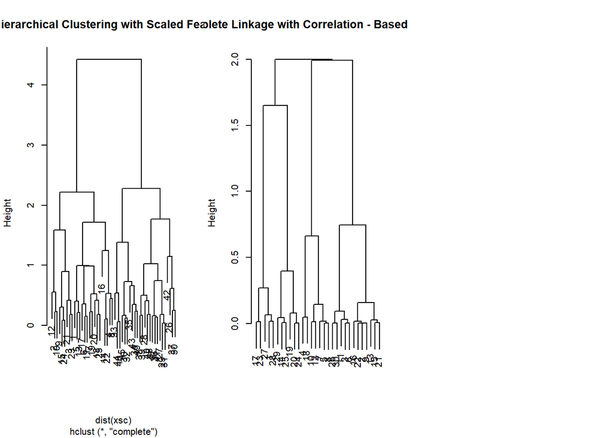

```r
xsc <- scale (x)
plot ( hclust ( dist (xsc), method = "complete") , main = "Hierarchical Clustering with Scaled Features")

x <- matrix ( rnorm (30 * 3), ncol = 3)
dd <- as.dist (1 - cor (t(x)))
plot ( hclust (dd, method = "complete") , main = " Complete Linkage with Correlation - Based Distance ", xlab = "", sub = "")
```

## Hierarchical Clustering Summary of Output

### Question 9

This R code chunk two different plot matrices depicting a total of five different hierarchical clustering trees. The first matrix contains trees for hierarchical clustering performed using complete, average, and single linkage. Each of these trees have been cut into two clusters, however the output for the single linkage tree produced using the cutree() function reveals that single linkage is not appropriate being that it separates only one observation into the second cluster. The same result is produced when the tree is cut into four clusters using single linkage, which separates only one observation into the fourth cluster.

# References

James, G., Witten, D., Hastie, T., Tibshirani, R. (2021). Heart.csv [Data set]. https://www.statlearning.com/resources-second-edition